# Making Backyards Affordable for All

Author

Sebastian Alejos

Published

November 2, 2025

# US Census Bureau Data

```
# A tibble: 10 × 4
   GEOID NAME                                           household_income  year
   <dbl> <chr>                                                     <dbl> <dbl>
 1 10140 Aberdeen, WA Micro Area                                   36345  2009
 2 10180 Abilene, TX Metro Area                                    42931  2009
 3 10300 Adrian, MI Micro Area                                     45640  2009
 4 10380 Aguadilla-Isabela-San Sebasti?n, PR Metro Area            13470  2009
 5 10420 Akron, OH Metro Area                                      47482  2009
 6 10500 Albany, GA Metro Area                                     36218  2009
 7 10540 Albany-Lebanon, OR Micro Area                             47669  2009
 8 10580 Albany-Schenectady-Troy, NY Metro Area                    57677  2009
 9 10700 Albertville, AL Micro Area                                37284  2009
10 10740 Albuquerque, NM Metro Area                                46824  2009
```

```
# A tibble: 10 × 4
   GEOID NAME                                           population  year
   <dbl> <chr>                                               <dbl> <dbl>
 1 10140 Aberdeen, WA Micro Area                             71797  2009
 2 10180 Abilene, TX Metro Area                             160266  2009
 3 10300 Adrian, MI Micro Area                               99837  2009
 4 10380 Aguadilla-Isabela-San Sebasti?n, PR Metro Area     342495  2009
 5 10420 Akron, OH Metro Area                               699935  2009
 6 10500 Albany, GA Metro Area                              164238  2009
 7 10540 Albany-Lebanon, OR Micro Area                      116584  2009
 8 10580 Albany-Schenectady-Troy, NY Metro Area             857592  2009
 9 10700 Albertville, AL Micro Area                          90399  2009
10 10740 Albuquerque, NM Metro Area                         856216  2009
```

# Number of New Housing Units Built this Year

```
# A tibble: 10 × 3
    CBSA new_housing_units_permitted  year
   <dbl>                       <dbl> <dbl>
 1 10180                         214  2009
 2 10420                         741  2009
 3 10500                         213  2009
 4 10580                        1380  2009
 5 10740                        1692  2009
 6 10780                         396  2009
 7 10900                        1648  2009
 8 11020                         125  2009
 9 11100                         642  2009
10 11180                         122  2009
```

# North American Industry Classification System (NAICS) coding system

```
# A tibble: 10 × 8
   level1_title   level2_title level3_title level4_title level1_code level2_code
   <chr>          <chr>        <chr>        <chr>              <dbl> <chr>
 1 Agriculture, … Crop produc… Oilseed and… Soybean far…          11 111
 2 Agriculture, … Crop produc… Oilseed and… Oilseed (ex…          11 111
 3 Agriculture, … Crop produc… Oilseed and… Dry pea and…          11 111
 4 Agriculture, … Crop produc… Oilseed and… Wheat farmi…          11 111
 5 Agriculture, … Crop produc… Oilseed and… Corn farming          11 111
 6 Agriculture, … Crop produc… Oilseed and… Rice farming          11 111
 7 Agriculture, … Crop produc… Oilseed and… Other grain…          11 111
 8 Agriculture, … Crop produc… Vegetable a… Vegetable a…          11 111
 9 Agriculture, … Crop produc… Fruit and t… Orange grov…          11 111
10 Agriculture, … Crop produc… Fruit and t… Citrus (exc…          11 111
# ℹ 2 more variables: level3_code <chr>, level4_code <chr>
```

# BLS Quarterly Census of Employment and Wages

```
# A tibble: 10 × 6
    YEAR FIPS  INDUSTRY EMPLOYMENT TOTAL_WAGES AVG_WAGE
   <dbl> <chr>    <dbl>      <dbl>       <dbl>    <dbl>
 1  2009 C1018      101       8050   342280951   42519.
 2  2009 C1018     1011       1769    86660038   48988.
 3  2009 C1018     1012       3328   151822573   45620.
 4  2009 C1018     1013       2952   103798340   35162.
 5  2009 C1018      102      42334  1284997543   30354.
 6  2009 C1018     1021      11993   368955371   30764.
 7  2009 C1018     1022          0           0      NA
 8  2009 C1018     1023       3575   138206437   38659.
 9  2009 C1018     1024       4697   149886226   31911.
10  2009 C1018     1025      11950   452254692   37846.
```

# Data Consolidation and Preliminary Analysis

### Q1: Which CBSA (by name) permitted the largest number of new housing units in the decade from 2010 to 2019 (inclusive)?

Answer: “Houston Sugar Land Baytown, TX Metro Area (CBSA 26420) permitted the largest number of new housing units in the US during 2010-2019, with a total of 482,075 units.

```
# A tibble: 1 × 3
   CBSA total_permits NAME
  <dbl>         <dbl> <chr>
1 26420        482075 Houston-Sugar Land-Baytown, TX Metro Area
```

### Q2: In what year did Albuquerque, NM (CBSA Number 10740) permit the most new housing units?

Answer: Albuquerque permitted the most housing units in 2021 with a total of 4,021

```
# A tibble: 15 × 3
    CBSA new_housing_units_permitted  year
   <dbl>                       <dbl> <dbl>
 1 10740                        4021  2021
 2 10740                        2852  2022
 3 10740                        2834  2023
 4 10740                        2606  2013
 5 10740                        2543  2014
 6 10740                        2465  2016
 7 10740                        2295  2015
 8 10740                        2256  2017
 9 10740                        2186  2018
10 10740                        2148  2019
11 10740                        2084  2012
12 10740                        2014  2020
13 10740                        1764  2010
14 10740                        1692  2009
15 10740                        1634  2011
```

```
# A tibble: 1 × 3
   CBSA new_housing_units_permitted  year
  <dbl>                       <dbl> <dbl>
1 10740                        4021  2021
```

### Q3: Which state (not CBSA) had the highest average individual income in 2015?

Answer: The District of Columbia (Washington DC) had the highest average individual income among all U.S. states and territories based on aggregated CBSA level data.

```
# A tibble: 1 × 5
  state total_income total_population avg_individual_income name
  <chr>        <dbl>            <dbl>                 <dbl> <chr>
1 DC    202663489140          6098283                33233. District of Columbia
```

### Q4: Data scientists and business analysts are recorded under NAICS code 5182. What is the last year in which the NYC CBSA had the most data scientists in the country? In recent, the San Francisco CBSA has had the most data scientists.

Answer: 2015 was the last year that NYC employed the largest number of data scientists and analysts in the country, as recorded under NAICS code 5182.

```
# A tibble: 1 × 4
   YEAR std_cbsa NAME                                                 EMPLOYMENT
  <dbl> <chr>    <chr>                                                     <dbl>
1  2015 C35620   New York-Northern New Jersey-Long Island, NY-NJ-PA …      18922
```

### Q5: What fraction of total wages in the NYC CBSA was earned by people employed in the finance and insurance industries (NAICS code 52)? In what year did this fraction peak?

Answer: New York City CBSA (C35620) earned approximately 4.6% of its total wages from the finance and insurance industries (NAICS 52). This fraction peaked in 2014 based on the datasheet.

```
# A tibble: 1 × 4
   YEAR   total_wages finance_wages finance_fraction
  <dbl>         <dbl>         <dbl>            <dbl>
1  2014 2587096519796  119105615711           0.0460
```

# Data Visualizations for overarching relationships

## The relationship between monthly rent and average household income per CBSA in 2009

Key Insights: There is a positive correlation given by the upward sloping red trend line. As average income increases, monthly rent tends to rise, suggesting that higher income regions generally face higher housing costs.

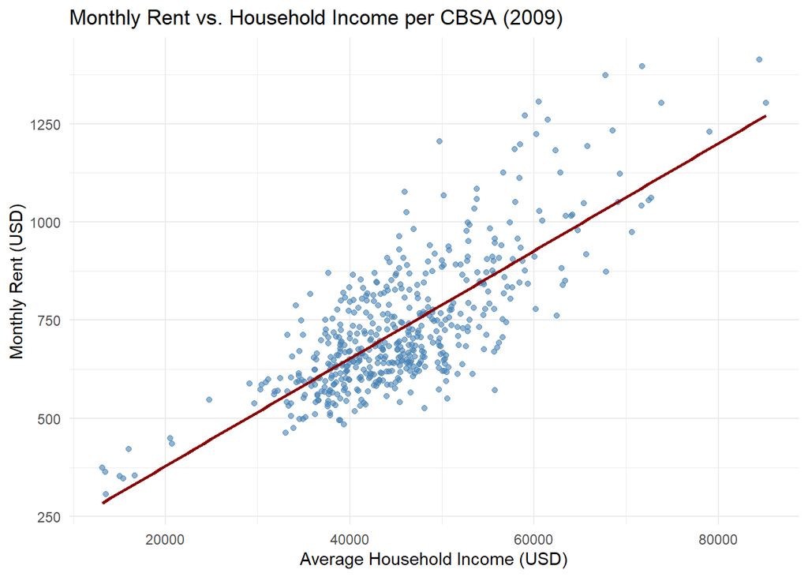

## The relationship between total employment, and total employment in the health care and social services sector (NAICS 62) across different CBSAs.

Key Insights: There is a consistency in positive correlation indicating that as total employment increases in a CBSA, health care and social services employment rises. This may suggest that the sector scales proportionally with regional labor markets.

```
    Min.  1st Qu.   Median     Mean  3rd Qu.     Max.
   11434   197841   363582  1307538   935852 43407668
```

```
   Min. 1st Qu.  Median    Mean 3rd Qu.    Max.
      0    4372    9826   35977   26553 1756931
```

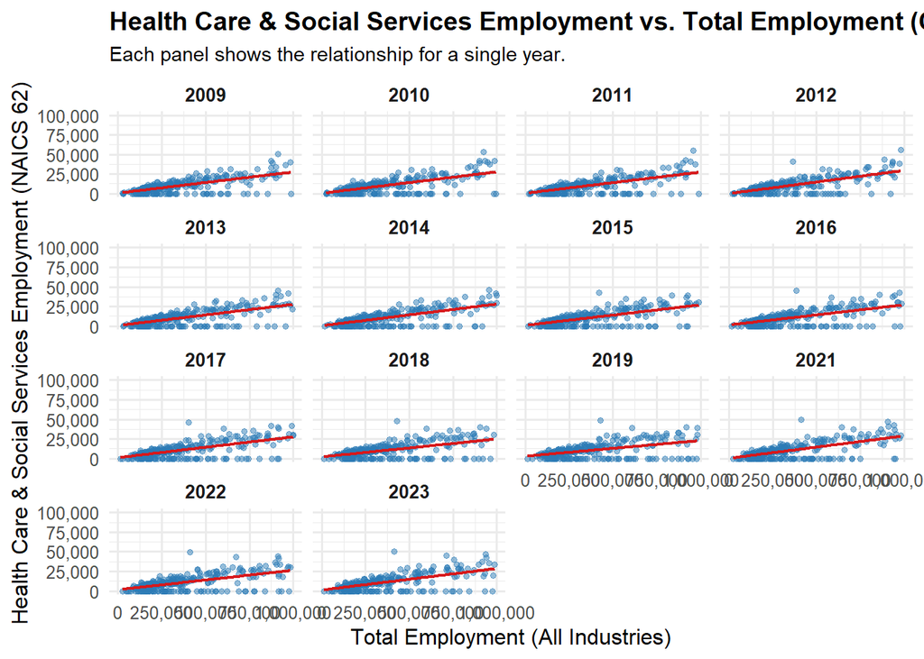

Key Insights: Line graph shows a consistent upward trajectory indicating the household formation steadily increasing in these regions over the decade. This reflects ongoing urban expansion, population growth, and housing development.

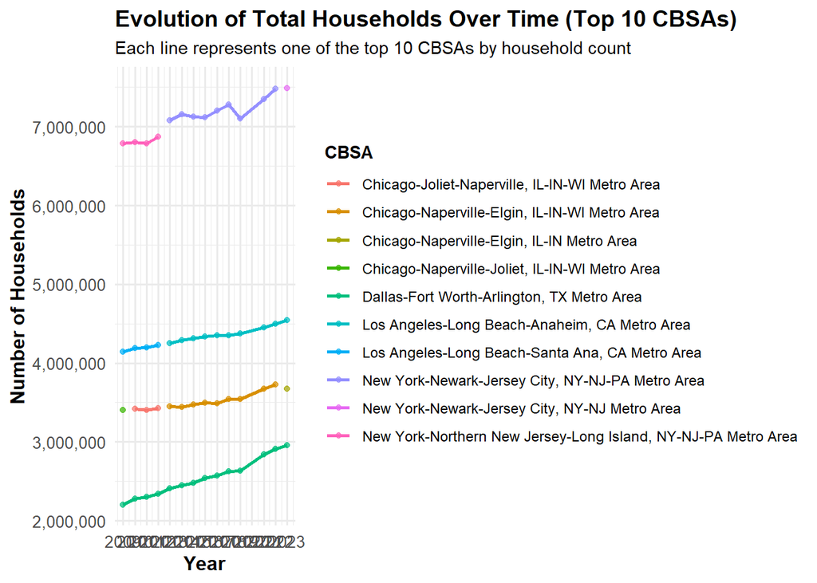

# Indices for Housing Affordability & Housing Stock Growth

The code constructs a standardized rent burden index to compare housing affordability across CBSAs over time. The creation of a rent_burden_index represents a normalized score that captures how much worse or better a CBSA’s rent burden is compared to the national average in the baseline year.

The code below defines three possibilities to scale or standardize the rent burden ratio, each producing a distinct metric that helps compare housing affordability across CBSAs. The ratio captures the share of income spent on rent.

# Rent Burden over time for a New York Metropolitan Area

Rent burden in NYC is consistently elevated compared to the national baseline, even as incomes rise for most new yorkers. The burden peaked mid-decade, eased slightly by 2019, and rebounded post-pandemic. This ultimately reflects NYC’s structural housing cost pressure growth often outpaces income gains.

| year | median_rent | median_income | rent_burden_ratio | rent_burden_index | rent_burden_log |
| --- | --- | --- | --- | --- | --- |
| 2013 | 1237 | 65786 | 0.2256407138296902 | 1.162880806713154 | 0.1509003805054087 |
| 2014 | 1281 | 67066 | 0.2292070497718665 | 1.181260573143863 | 0.1665821505953765 |
| 2015 | 1308 | 68743 | 0.228328702558806 | 1.176733849671125 | 0.1627426766849627 |
| 2016 | 1346 | 71897 | 0.2246547143830758 | 1.15779927770876 | 0.1465210288145507 |
| 2017 | 1379 | 75368 | 0.2195626791211124 | 1.131556539983186 | 0.1235941538957933 |
| 2018 | 1434 | 78478 | 0.2192716430082316 | 1.130056631992358 | 0.12226774827584 |
| 2019 | 1482 | 83160 | 0.2138528138528139 | 1.102129701994923 | 0.0972444007150783 |
| 2021 | 1600 | 84409 | 0.2274638960300442 | 1.172276910598612 | 0.1589479350888443 |
| 2022 | 1685 | 91562 | 0.2208339704244119 | 1.138108372900468 | 0.1293675621896971 |

# Visualizations that investigate the relationships between Rent Burden and Housing Growth Metrics

## Highlighting Metro Area with the highest and lowest rent burden

| NAME | median_rent | median_income | rent_burden_ratio | rent_burden_index | rent_burden_log |
| --- | --- | --- | --- | --- | --- |
| Clearlake, CA Micro Area | 1544 | 59444 | 0.3116883116883117 | 1.606342885498673 | 0.4739600955372567 |
| Aguadilla, PR Metro Area | 548 | 21290 | 0.3088774072334429 | 1.591856373802302 | 0.4649008658914856 |
| Cape Coral-Fort Myers, FL Metro Area | 1797 | 71547 | 0.3013962849595371 | 1.55330103794405 | 0.4403823682301647 |
| Miami-Fort Lauderdale-West Palm Beach, FL Metro Area | 1914 | 76271 | 0.3011367361120216 | 1.551963405350811 | 0.4395208424564983 |
| Port St. Lucie, FL Metro Area | 1679 | 68316 | 0.2949235903741437 | 1.519942819148698 | 0.4186727151694539 |
| Ponce, PR Metro Area | 502 | 20978 | 0.287157975021451 | 1.479921296025972 | 0.3919889080011751 |
| Tampa-St. Petersburg-Clearwater, FL Metro Area | 1729 | 72743 | 0.2852233204569512 | 1.469950698865148 | 0.385228862041253 |
| Key West-Key Largo, FL Micro Area | 2091 | 88870 | 0.2823449983121413 | 1.455116737737622 | 0.3750861295271079 |
| North Port-Bradenton-Sarasota, FL Metro Area | 1854 | 78914 | 0.2819271612134729 | 1.452963337608153 | 0.3736051520661973 |
| Ocala, FL Metro Area | 1365 | 58606 | 0.2794935672115483 | 1.440421364538938 | 0.3649356850478571 |

| NAME | median_rent | median_income | rent_burden_ratio | rent_burden_index | rent_burden_log |
| --- | --- | --- | --- | --- | --- |
| Laconia, NH Micro Area | 1037 | 97692 | 0.1273799287556811 | 0.6564758274177187 | -0.4208694063014554 |
| Manitowoc, WI Micro Area | 752 | 68297 | 0.1321287904300335 | 0.6809499571131614 | -0.3842664599480649 |
| Bismarck, ND Metro Area | 951 | 83440 | 0.1367689357622243 | 0.7048637971980545 | -0.3497506902982685 |
| Watertown-Fort Atkinson, WI Micro Area | 953 | 82864 | 0.1380092681984939 | 0.7112560779154887 | -0.3407227481784754 |
| Wisconsin Rapids-Marshfield, WI Micro Area | 766 | 66461 | 0.1383066760957554 | 0.7127888240658636 | -0.3385700818683974 |
| Jefferson City, MO Metro Area | 792 | 68629 | 0.1384837313672063 | 0.7137013108835265 | -0.3372907362637357 |
| Decatur, AL Metro Area | 854 | 72956 | 0.1404682274247492 | 0.7239287753208903 | -0.3230622680643232 |
| Talladega-Sylacauga, AL Micro Area | 728 | 61514 | 0.1420164515394869 | 0.7319078322781287 | -0.3121006851367793 |
| Mount Airy, NC Micro Area | 697 | 58291 | 0.1434869876996449 | 0.7394865101115805 | -0.3017992389022246 |
| Albertville, AL Micro Area | 724 | 60298 | 0.1440843809081561 | 0.7425652855880793 | -0.2976444854526577 |

# Housing Growth

The code below constructs two standardized metrics to evaluate housing growth across U.S. Core-based Statistical Areas (CBSAs) using permit and population data. The metric captures both instantaneous and rate-based housing development, then scales them for comparison.

```
# A tibble: 2,122 × 11
   GEOID NAME                population  year permits pop_5yr_ago pop_growth_5yr
   <dbl> <chr>                    <dbl> <dbl>   <dbl>       <dbl>          <dbl>
 1 10180 Abilene, TX Metro …     166900  2014     284      160266           6634
 2 10420 Akron, OH Metro Ar…     703825  2014     763      699935           3890
 3 10580 Albany-Schenectady…     880167  2014    2231      857592          22575
 4 10740 Albuquerque, NM Me…     905213  2014    2543      856216          48997
 5 10780 Alexandria, LA Met…     154872  2014     323      154101            771
 6 10900 Allentown-Bethlehe…     829835  2014    1801      816012          13823
 7 11100 Amarillo, TX Metro…     261752  2014     918      245712          16040
 8 11180 Ames, IA Metro Area      94073  2014     539       87214           6859
 9 11260 Anchorage, AK Metr…     398892  2014     887      374553          24339
10 11460 Ann Arbor, MI Metr…     356874  2014     570      347563           9311
# ℹ 2,112 more rows
# ℹ 4 more variables: permits_per_1000 <dbl>, permits_per_growth <dbl>,
#   permits_per_1000_scaled <dbl>, permits_per_growth_scaled <dbl>
```

## High and Low Scoring CBSA’s

The table identifies the top and bottom CBSAs based on their instantaneous growth measure by the number of housing permits issued per 1,000 residents in a given year.

```
# A tibble: 20 × 8
   rank_type         GEOID NAME         year permits population permits_per_1000
   <chr>             <dbl> <chr>       <dbl>   <dbl>      <dbl>            <dbl>
 1 Top Performers    45540 The Villag…  2021    4611     135638          34.0
 2 Top Performers    45540 The Villag…  2022    4439     144970          30.6
 3 Top Performers    39460 Punta Gord…  2022    5676     202661          28.0
 4 Top Performers    39460 Punta Gord…  2021    4830     194843          24.8
 5 Top Performers    34820 Myrtle Bea…  2021   12219     509794          24.0
 6 Top Performers    34820 Myrtle Bea…  2022   12000     536165          22.4
 7 Top Performers    45540 The Villag…  2019    2928     132420          22.1
 8 Top Performers    39460 Punta Gord…  2023    4429     206134          21.5
 9 Top Performers    41100 St. George…  2019    3557     177556          20.0
10 Top Performers    41100 St. George…  2017    3209     165662          19.4
11 Bottom Performers 21820 Fairbanks,…  2015       7      99631           0.0703
12 Bottom Performers 34060 Morgantown…  2022      11     141041           0.0780
13 Bottom Performers 21820 Fairbanks,…  2016      11     100605           0.109
14 Bottom Performers 34060 Morgantown…  2023      17     141817           0.120
15 Bottom Performers 34060 Morgantown…  2021      21     140745           0.149
16 Bottom Performers 34060 Morgantown…  2016      21     138380           0.152
17 Bottom Performers 21420 Enid, OK M…  2023      10      62023           0.161
18 Bottom Performers 34060 Morgantown…  2019      34     139044           0.245
19 Bottom Performers 13780 Binghamton…  2014      85     247219           0.344
20 Bottom Performers 26300 Hot Spring…  2017      38      98658           0.385
# ℹ 1 more variable: permits_per_1000_scaled <dbl>
```

## Top 10 & Bottom 10 CBSAs by permits per growth

The table below demonstrates a ranked comparison of U.S. Core - Based Statistical Areas based on how actively they permitted new housing relative to their 5 year population growth.

Top performers are indicated by CBSAs that permitted an increment in housing units relative their population growth.

Low performers show very few housing units despite significant population growth - indicating potential underbuilding, regulatory constraints, or housing supply shortages.

```
# A tibble: 20 × 8
   rank_type         GEOID NAME   year permits pop_growth_5yr permits_per_growth
   <chr>             <dbl> <chr> <dbl>   <dbl>          <dbl>              <dbl>
 1 Top Performers    33660 Mobi…  2017     998             19           52.5
 2 Top Performers    35100 New …  2019     552             18           30.7
 3 Top Performers    48140 Waus…  2018     308             12           25.7
 4 Top Performers    22520 Flor…  2017     775             50           15.5
 5 Top Performers    38300 Pitt…  2021    5223            493           10.6
 6 Top Performers    17860 Colu…  2017    1634            170            9.61
 7 Top Performers    10580 Alba…  2019    1870            214            8.74
 8 Top Performers    33780 Monr…  2018     492             63            7.81
 9 Top Performers    30340 Lewi…  2017     252             42            6
10 Top Performers    22540 Fond…  2016     365             65            5.62
11 Bottom Performers 34060 Morg…  2016      21           6129            0.00343
12 Bottom Performers 26580 Hunt…  2016     250          71989            0.00347
13 Bottom Performers 26580 Hunt…  2017     264          69871            0.00378
14 Bottom Performers 12100 Atla…  2023     383          99905            0.00383
15 Bottom Performers 26580 Hunt…  2015     291          73969            0.00393
16 Bottom Performers 30980 Long…  2019     276          69176            0.00399
17 Bottom Performers 34060 Morg…  2022      11           2661            0.00413
18 Bottom Performers 26580 Hunt…  2014     358          77701            0.00461
19 Bottom Performers 30980 Long…  2023     364          76017            0.00479
20 Bottom Performers 16620 Char…  2022     160          30975            0.00517
# ℹ 1 more variable: permits_per_growth_scaled <dbl>
```

## Composite Score

The table summary displays the top 10 and bottom 10 CBSAs based on their rolling 5-year composite scores:

```
# A tibble: 20 × 5
   rank_type         GEOID NAME                         year composite_score_5yr
   <chr>             <dbl> <chr>                       <dbl>               <dbl>
 1 Top Performers    39460 Punta Gorda, FL Metro Area   2023              28.9
 2 Top Performers    41100 St. George, UT Metro Area    2022              26.7
 3 Top Performers    41100 St. George, UT Metro Area    2021              26.0
 4 Top Performers    41100 St. George, UT Metro Area    2023              25.1
 5 Top Performers    39460 Punta Gorda, FL Metro Area   2022              24.6
 6 Top Performers    41100 St. George, UT Metro Area    2019              23.8
 7 Top Performers    15980 Cape Coral-Fort Myers, FL …  2023              22.0
 8 Top Performers    24540 Greeley, CO Metro Area       2022              21.1
 9 Top Performers    41100 St. George, UT Metro Area    2018              21.0
10 Top Performers    24540 Greeley, CO Metro Area       2023              20.5
11 Bottom Performers 34060 Morgantown, WV Metro Area    2023               0.646
12 Bottom Performers 34060 Morgantown, WV Metro Area    2022               0.776
13 Bottom Performers 34060 Morgantown, WV Metro Area    2021               0.798
14 Bottom Performers 26300 Hot Springs, AR Metro Area   2019               1.00
15 Bottom Performers 30020 Lawton, OK Metro Area        2022               1.05
16 Bottom Performers 26580 Huntington-Ashland, WV-KY-…  2023               1.09
17 Bottom Performers 34060 Morgantown, WV Metro Area    2019               1.11
18 Bottom Performers 45460 Terre Haute, IN Metro Area   2023               1.23
19 Bottom Performers 25620 Hattiesburg, MS Metro Area   2023               1.24
20 Bottom Performers 34060 Morgantown, WV Metro Area    2018               1.25
```

# Rent Burden Change & Housing Growth Graphical Analysis

## Visualization 2 - Rent Burden and Population over time

CBSA that show increasing population (red line trending upwards) and decreasing rent burden (blue line trending downward) should be taken into consideration. These regions likely meet the sufficient housing to satisfy the demand, improving affordability without sacrificing growth.

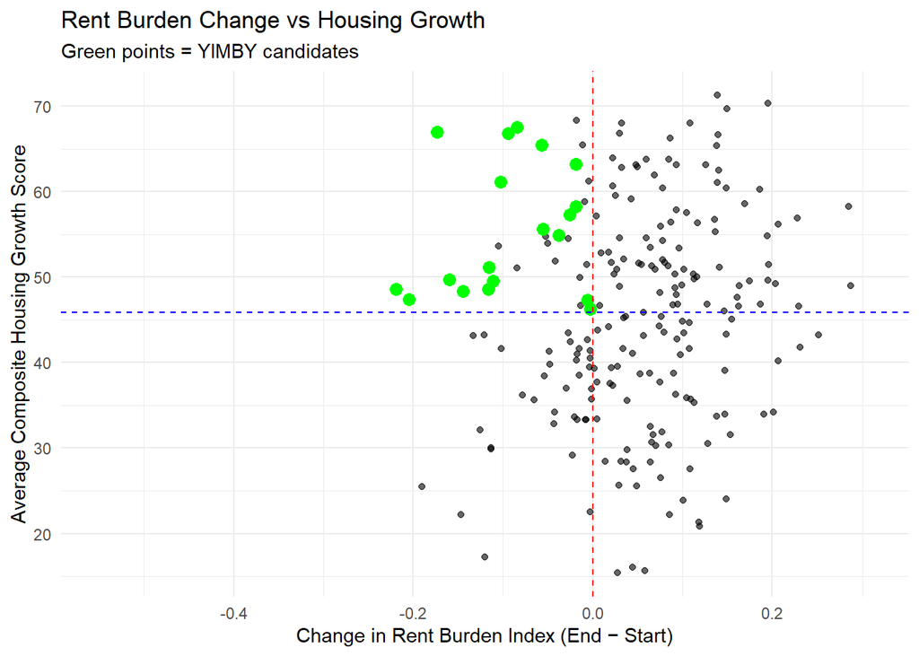

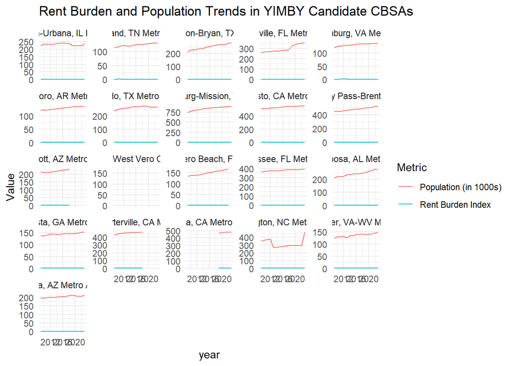

# Policy Brief: Federal YIMBY Incentive Progam

Prepared for Congressional Sponsors from Houston, TX and New York, NY

# Executive Summary

We propose a federal grant program to reward municipalities that adopt pro-housing (“YIMBY”) policies - streamlining zoning, permitting, and land use to increase housing supply. This program will reduce rent burdens, support working families, and stimulate local economies.

This policy will directly benefit essential workers which represent a sizable and politically active constituencies in cities like New York and Houston. In New York City, the FDNY employs over 10,000 firefighters, many of whom face rent burdens that exceed 30% of their income—making affordable housing a critical issue for union leadership. Similarly, Houston’s growing population of home health aides, a workforce dominated by women and people of color, often earns below the median wage and struggles to find housing near their clients. By incentivizing municipalities to expand housing supply, this bill would reduce rent pressure for these workers, allowing them to live closer to their jobs, spend more on local goods and services, and stabilize their families.

To identify cities that merit federal support under this YIMBY incentive program, we recommend two simple, transparent metrics. First, the Rent Burden Index measures how much of a household’s income goes toward rent.The higher values indicate a greater financial strain. By tracking changes in this index over time, we can identify cities that are improving affordability. Second, the Composite Housing Growth Score captures how actively a city is building housing, combining two factors: housing permits per capita and housing permits per net new resident. This score reveals which metropolitan cities are expanding supply in response to demand, not just benefiting from population decline. Together, these metrics allow the federal government to target funding toward cities that are growing responsibly and making measurable progress on affordability.